# The Study of Depression in Teenagers: How can mental health and lifestyle indicators support the identification of depression in teenagers?

# Introduction

## Data Source

The present study leerages the public dataset from the National Longitudinal Study of Adolescent to Adult Health (Add Health), 1994-2018 [Public Use] (ICPSR 21600)

Harris, Kathleen Mullan, and Udry, J. Richard. National Longitudinal Study of Adolescent to Adult Health (Add Health), 1994-2018 [Public Use]. Carolina Population Center, University of North Carolina-Chapel Hill [distributor], Inter-university Consortium for Political and Social Research [distributor], 2022-08-09. https://doi.org/10.3886/ICPSR21600.v25

## Background and Objective

# Library Load

```r
library(tidyverse)
library(kableExtra)
library(wesanderson)
library(patchwork)
library(caTools)
library(splitTools)
```

# Data Load

```r
# Loads the questionnaire responses for wave 1
load("C:/Users/i.madiedo.soto/OneDrive - Accenture/Documents/SoD/Healthcare Analytics/Data/21600-0001-Data.rda")

# Converts the data into a data frame
df = data.frame(da21600.0001)
```

# Variable Selection

## Rationale

To achieve the objective of this study, four variable categories are extracted from the AdHealth Wave I dataset:

1. Depression: the health measure is captured from the dataset categorical question: How often during the past week did you feel depressed? On the one hand, this variable enquires directly about depression. As a result, the study can focus on participants with the specified mental disorder over participants having a bad week or feeling under the weather. On the other hand, this variable refers to a recent timeframe (latest week) which aligns with the measurement of several of the accompanying mental health and life style indicators used in this report. In relation, given the self-reporting nature of the dataset, a recent timeframe allows for the most accurate recollections by the participants.
2. Mental Health Indicators: the report studies two areas of mental health – (1) self-esteem/ self-consciousness via the participants’ categorical perception of their weight and intelligence, and (2) state of mind via the respondents’ categorical degree of loneliness and life enjoyment (latest week timeframe). These variables capture central topics of adolescence, such as physical appearance, overachievement, and social relationships. Thus, and in line with the literature review, providing essential resource for the identification of depression.
3. Life style Indicators: this category captures – (1) exercise habits which have been found to correlate with depression, (2) school relationships, which provide an indication of social dynamics associated with depression as bullying/ peer pressure, and (3) alcohol/drugs/cigarettes consumption, which reviews substance abuse (all categorical measurements in a weekly or yearly timeframe). Going forward, areas (1) and (2) are denoted Part A and area (3) Part B of the life style indicators.
4. Gender & Socioeconomic Factors: this category controls for gender, education, income, and unemployment (the two latter corresponds to the parents/ household). These factors were selected to account for confounding variables which have the potential to distort the relationship between mental health/ life style indicators and depression. For instance, exercise and physical activity may not be affordable to all respondents.

## Variable Extraction

```r
# Selects the relevant variables (for this study) from the whole set of wave 1 in a clean format
data <- df %>%
  select(H1FS6, BIO_SEX, PA55, H1GI18, PA57E, H1DA6, S63, H1SE4, H1GH28,
         H1ED18, H1FS13, H1ED17, H1TO51, H1TO40, H1TO3, H1FS15) %>%
  mutate(H1FS6 = if_else(H1FS6 == '(0) (0) Never/rarely',
                              'No',
                              'Yes',
                              missing = NULL),
         BIO_SEX = if_else(BIO_SEX == '(1) (1) Male',
                              'Male',
                              'Female',
                              missing = NULL),
         H1GI18 = if_else(H1GI18 == '(0) (0) No (skip to Q.21)',
                              'No',
                              'Yes',
                              missing = NULL),
         PA57E = if_else(PA57E == '(0) (0) No',
                              'No',
                              'Yes',
                              missing = NULL),
         H1DA6 = case_when(H1DA6 == '(0) (0) Not at all' ~ '0. Not at all',
                              H1DA6 == '(1) (1) 1 or 2 times' ~ '1. 1 or 2 times',
                              H1DA6 == '(2) (2) 3 or 4 times' ~ '2. 3 or 4 times',
                              H1DA6 == '(3) (3) 5 or more times' ~ '3. 5 or more times'),
         S63 = case_when(S63 == '(0) (0) Never' ~ '0. Never',
                              S63 == '(1) (1) 1 or 2 times' ~ '1. 1 or 2 times',
                              S63 == '(2) (2) 3 to 5 times' ~ '2. 3 or 5 times',
                              S63 == '(3) (3) 6 or 7 times' ~ '3. 6 or 7 times',
                              S63 == '(4) (4) More than 7 times' ~ '4. 7 or more times'),
         H1SE4 = case_when(H1SE4 == '(1) (1) Moderately below average' ~ '1. Moderately below average',
                              H1SE4 == '(2) (2) Slightly below average' ~ '2. Slightly below average',
                              H1SE4 == '(3) (3) About average' ~ '3. About average',
                              H1SE4 == '(4) (4) Slightly above average' ~ '4. Slightly above average',
                              H1SE4 == '(5) (5) Moderately above average' ~ '5. Moderately above average',
                              H1SE4 == '(6) (6) Extremely above average' ~ '6. Extremely above average'),
         H1GH28 = case_when(H1GH28 == '(1) (1) Very underweight' ~ '1. Very underweight',
                              H1GH28 == '(2) (2) Slightly underweight' ~ '2. Slightly underweight',
                              H1GH28 == '(3) (3) About the right weight' ~ '3. About the right weight',
                              H1GH28 == '(4) (4) Slightly overweight' ~ '4. Slightly overweight',
                              H1GH28 == '(5) (5) Very overweight' ~ '5. Very overweight'),
         H1ED18 = case_when(H1ED18 == '(0) (0) Never' ~ '0. Never',
                              H1ED18 == '(1) (1) Just a few times' ~ '1. Just a few times',
                              H1ED18 == '(2) (2) About once a week' ~ '2. About once a week',
                              H1ED18 == '(3) (3) Almost every day' ~ '3. Almost every day',
                              H1ED18 == '(4) (4) Every day' ~ '4. Every day'),
         H1FS13 = case_when(H1FS13 == '(0) (0) Never/rarely' ~ '0. Never/rarely',
                              H1FS13 == '(1) (1) Sometimes' ~ '1. Sometimes',
                              H1FS13 == '(2) (2) A lot of the time' ~ '2. A lot of the time',
                              H1FS13 == '(3) (3) Most/all of the time' ~ '3. Most/all of the time'),
         H1ED17 = case_when(H1ED17 == '(0) (0) Never' ~ '0. Never',
                              H1ED17 == '(1) (1) Just a few times' ~ '1. Just a few times',
                              H1ED17 == '(2) (2) About once a week' ~ '2. About once a week',
                              H1ED17 == '(3) (3) Almost every day' ~ '3. Almost every day',
                              H1ED17 == '(4) (4) Every day' ~ '4. Every day'),
         H1TO51 = if_else(H1TO51 == '(0) (0) No',
                              'No',
                              'Yes',
                              missing = NULL),
         H1TO40 = if_else(H1TO40 == '(00) (0) You never tried any other type of illegal drug',
                              '0. Never',
                              if_else(H1TO40 == '(01) (1) 1 year' | H1TO40 == '(03) (3) 2-3 years' | H1TO40 == '(06) (6) 4-6 years' | H1TO40 == '(09) (9) 8-9 years' | H1TO40 == '(11) (11) 10-11 years',
                                      '1. Before 12 years old',
                                      '2. After 12 years old'),
                              missing = NULL),
         H1TO3 = if_else(H1TO3 == '(0) (0) No (skip to Q.5)',
                              'No',
                              'Yes',
                              missing = NULL),
         H1FS15 = case_when(H1FS15 == '(0) (0) Never/rarely' ~ '0. Never/rarely',
                              H1FS15 == '(1) (1) Sometimes' ~ '1. Sometimes',
                              H1FS15 == '(2) (2) A lot of the time' ~ '2. A lot of the time',
                              H1FS15 == '(3) (3) Most/all of the time' ~ '3. Most/all of the time'))

# Converts the selected variables back to factors
data <- as.data.frame(unclass(data), stringsAsFactors = TRUE)

# Renames the variables with a representative name
data <- data %>%
  rename('Last Week Felt Depressed' = H1FS6, 'Gender' = BIO_SEX, 'Household Income' = PA55,
         'Currently in School' = H1GI18, 'Unemployment Compensation' = PA57E, 'Last Week Exercise' = H1DA6,
         'Weekly Break a Sweat' = S63, 'Intelligence Perception' = H1SE4, 'Weight Perception' = H1GH28,
         'Last Year Trouble Other Students' = H1ED18, 'Last Week Felt Lonely' = H1FS13,
         'Last Year Trouble HW' = H1ED17, 'Easy Access Alcohol at Home' = H1TO51,
         'Age First Drugs' = H1TO40, 'Regular Smoker' = H1TO3, 'Last Week Enjoyed Life' = H1FS15)
```

# Exploratory Data Analysis

## Summary Statistics

### Mental Health

```r
# Calculates and formats the summary statistics for the mental health variables
options(knitr.kable.NA = '')

data %>%
  select('Last Week Felt Depressed', 'Last Week Felt Lonely', 'Last Week Enjoyed Life', 'Weight Perception', 'Intelligence Perception') %>%
  summary() %>%
  kbl(caption = "Summary Statistics: Individual's Mental Health", col.names = c('Last Week Felt Depressed',
                                                                       'Last Week Felt Lonely',
                                                                       'Last Week Enjoyed Life',
                                                                       'Weight Perception',
                                                                       'Intelligence Perception')) %>%
  kable_classic(full_width = T, html_font = 'Times New Roman') %>%
  add_header_above(c("Number of Records" = 6)) %>%
  footnote(general = '',
           general_title = "Notes:",
           alphabet = c("Last Week Depression: based on 'How often during the past week did you feel depressed?'. Where, 'Never/Rarely' responses are recorded as a 'No' and any other response (Sometimes, A lot of the time, Most/all of the time) is recorded as a 'Yes'.",
                        "Intelligence Perception and Weight Perception correspond to the individual's own perspective at the time of the study."))
```

Summary Statistics: Individual’s Mental Health

Number of Records

Last Week Felt Depressed

Last Week Felt Lonely

Last Week Enjoyed Life

Weight Perception

Intelligence Perception

No :3994

0. Never/rarely :4157
0. Never/rarely : 255
1. Very underweight : 128
1. Moderately below average: 77

Yes :2490

1. Sometimes :1787
1. Sometimes :1043
2. Slightly underweight : 935
2. Slightly below average : 322

NA’s: 20

2. A lot of the time : 401
2. A lot of the time :2047
3. About the right weight:3381
3. About average :2502
3. Most/all of the time: 140
3. Most/all of the time:3141
4. Slightly overweight :1808
4. Slightly above average :1420

NA’s : 19

NA’s : 18

5. Very overweight : 238
5. Moderately above average:1735

NA’s : 14

6. Extremely above average : 418

NA’s : 30

Notes:

<sup>a</sup> Last Week Depression: based on ‘How often during the past week did you feel depressed?’. Where, ‘Never/Rarely’ responses are recorded as a ‘No’ and any other response (Sometimes, A lot of the time, Most/all of the time) is recorded as a ‘Yes’.

<sup>b</sup> Intelligence Perception and Weight Perception correspond to the individual’s own perspective at the time of the study.

### Life Style

```r
#Calculates and formats the summary statistics for the life style variables (Part A)
options(knitr.kable.NA = '')

data %>%
  select('Last Week Exercise', 'Weekly Break a Sweat', 'Last Year Trouble Other Students', 'Last Year Trouble HW') %>%
  summary() %>%
  kbl(caption = "Summary Statistics: Individual's Life Style (Part A)", col.names = c('Last Week Exercise',
                                                                                'Weekly Break a Sweat',
                                                                                'Last Year Trouble Other Students',
                                                                                'Last Year Trouble HW')) %>%
  kable_classic(full_width = T, html_font = 'Times New Roman') %>%
  add_header_above(c("Number of Records" = 5)) %>%
  footnote(general = '',
           general_title = "Notes:",
           alphabet = c("Weekly Break a Sweat: based on 'How many times in a normal week do you work, play, or exercise hard enough to make you sweat and breathe heavily?'",
                        "Last Year Trouble Other Students: based on 'For the latest school year how often have you had trouble with getting along with other students?'",
                        "Last Year Trouble HW: based on 'For the latest school year how often have you had trouble with getting your homework done?'"))
```

Summary Statistics: Individual’s Life Style (Part A)

Number of Records

Last Week Exercise

Weekly Break a Sweat

Last Year Trouble Other Students

Last Year Trouble HW

0. Not at all :1072
0. Never : 231
0. Never :2496
0. Never :1892
1. 1 or 2 times :2059
1. 1 or 2 times : 958
1. Just a few times :2856
1. Just a few times :2633
2. 3 or 4 times :1618
2. 3 or 5 times :1362
2. About once a week: 514
2. About once a week:1004
3. 5 or more times:1749
3. 6 or 7 times : 732
3. Almost every day : 295
3. Almost every day : 580

NA’s : 6

4. 7 or more times:1029
4. Every day : 207
4. Every day : 258

NA’s :2192

NA’s : 136

NA’s : 137

Notes:

<sup>a</sup> Weekly Break a Sweat: based on ‘How many times in a normal week do you work, play, or exercise hard enough to make you sweat and breathe heavily?’

<sup>b</sup> Last Year Trouble Other Students: based on ‘For the latest school year how often have you had trouble with getting along with other students?’

<sup>c</sup> Last Year Trouble HW: based on ‘For the latest school year how often have you had trouble with getting your homework done?’

```r
#Calculates and formats the summary statistics for the life style variables (Part B)
options(knitr.kable.NA = '')

data %>%
  select('Easy Access Alcohol at Home', 'Age First Drugs', 'Regular Smoker') %>%
  summary() %>%
  kbl(caption = "Summary Statistics: Individual's Life Style (Part B)", col.names = c('Easy Access Alcohol at Home',
                                                                                      'Age First Drugs',
                                                                                      'Regular Smoker')) %>%
  kable_classic(full_width = T, html_font = 'Times New Roman') %>%
  add_header_above(c("Number of Records" = 4)) %>%
  footnote(general = '',
           general_title = "Notes:",
           alphabet = c("Easy Access Alcohol at Home: based on 'Is alcohol easily available to you in your home?'",
                        "Age First Drugs: based on the age the individual first tried illegal drugs other than marihuana or cocaine without a doctor's prescription. The responses are reclassified into 'before 12 years old' and 'After 12 years old' (inclusive)."))
```

Summary Statistics: Individual’s Life Style (Part B)

Number of Records

Easy Access Alcohol at Home

Age First Drugs

Regular Smoker

No :4625

0. Never :5903

No :1477

Yes :1825

1. Before 12 years old: 39

Yes :1285

NA’s: 54

2. After 12 years old : 460

NA’s:3742

NA’s : 102

Notes:

<sup>a</sup> Easy Access Alcohol at Home: based on ‘Is alcohol easily available to you in your home?’

<sup>b</sup> Age First Drugs: based on the age the individual first tried illegal drugs other than marihuana or cocaine without a doctor’s prescription. The responses are reclassified into ‘before 12 years old’ and ‘After 12 years old’ (inclusive).

```r
#Calculates and formats the summary statistics for gender and socioeconomic factors
options(knitr.kable.NA = '')

data %>%
  select('Gender', 'Currently in School', 'Household Income', 'Unemployment Compensation') %>%
  summary() %>%
  kbl(caption = "Summary Statistics: Gender and Socioeconomic Factors", col.names = c('Gender',
                                                                                      'Currently in School',
                                                                                      'Household Income',
                                                                                      'Unemployment Compensation')) %>%
  kable_classic(full_width = T, html_font = 'Times New Roman') %>%
  add_header_above(c("Number of Records (Discrete Varibales) & Statistics (Continous Variables)" = 5)) %>%
  footnote(general = '',
           general_title = "Notes:",
           alphabet = c("Household Income: family income before taxes (in thousands of dollars) for 1994, as reported by the parent.",
           "Unemployment Compensation: based on a question for the parents only: 'Last month, did you or any member of your household receive: Unemployment or worker's compensations?'"))
```

Summary Statistics: Gender and Socioeconomic Factors

| Number of Records (Discrete Varibales) & Statistics (Continous Variables) | Number of Records (Discrete Varibales) & Statistics (Continous Variables) Gender | Number of Records (Discrete Varibales) & Statistics (Continous Variables) Currently in School | Number of Records (Discrete Varibales) & Statistics (Continous Variables) Household Income | Number of Records (Discrete Varibales) & Statistics (Continous Variables) Unemployment Compensation |
| --- | --- | --- | --- | --- |
|  | Female:3356 | No : 125 | Min. : 0.0 | No :5294 |
|  | Male :3147 | Yes :6376 | 1st Qu.: 22.0 | Yes : 278 |
|  | NA’s : 1 | NA’s: 3 | Median : 40.0 | NA’s: 932 |
|  |  |  | Mean : 47.7 |  |
|  |  |  | 3rd Qu.: 60.0 |  |
|  |  |  | Max. :999.0 |  |
|  |  |  | NA’s :1575 |  |

Notes:  
<sup>a</sup> Household Income: family income before taxes (in thousands of dollars) for 1994, as reported by the parent.  
<sup>b</sup> Unemployment Compensation: based on a question for the parents only: ‘Last month, did you or any member of your household receive: Unemployment or worker’s compensations?’

## Visualisations

### Health Measure and Meantal Health

```r
# Calculates and graphs depression answers by a breakdown of loneliness

labels <- data %>%
  filter(!is.na(`Last Week Felt Depressed`), !is.na(`Last Week Felt Lonely`)) %>%
  group_by(`Last Week Felt Depressed`, `Last Week Felt Lonely`) %>%
  summarise(count = n()) %>%
  mutate(perc = ifelse(`Last Week Felt Depressed` == 'No', round(count/3993,2), round(count/2489,2)),
         perc=scales::percent(perc))
p <- data %>%
  filter(!is.na(`Last Week Felt Depressed`), !is.na(`Last Week Felt Lonely`)) %>%
  ggplot(aes(x = `Last Week Felt Depressed`, fill = `Last Week Felt Lonely`)) +
  geom_bar(position="stack", alpha = 1) +
  labs(y = '') +
  ggtitle('Depression and Loneliness in Teenagers') +
  annotate("text", y = 2300, x = 1, label = labels$perc[1], color = "white", size = 5.5, family ='serif') +
  annotate("text", y = 400, x = 1, label = labels$perc[2], color = "white", size = 5.5, family ='serif') +
  annotate("text", y = 2000, x = 2, label = labels$perc[5], color = "white", size = 5.5, family ='serif') +
  annotate("text", y = 1000, x = 2, label = labels$perc[6], color = "white", size = 5.5, family ='serif') +
  annotate("text", y = 305, x = 2, label = labels$perc[7], color = "white", size = 5.5, family ='serif') +
  annotate("text", y = 85, x = 2, label = labels$perc[8], color = "white", size = 5.5, family ='serif') +
  annotate("text", y = 3993, x = 1, label = 'n = 3993', color = "gray27", vjust = -0.3, size = 4.5, family ='serif') +
  annotate("text", y = 2489, x = 2, label = 'n = 2489', color = "gray27", vjust = -0.3, size = 4.5, family ='serif') +
  scale_fill_manual(values= wes_palette("GrandBudapest1", n = 4))  +
  theme_bw(base_size = 13) +
  theme(text = element_text(family = "serif"), plot.title = element_text(hjust = 0.5))
```

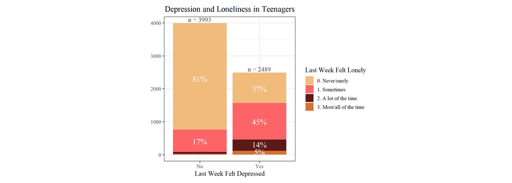

```r
# Outputs the graph of depression answers by a breakdown of loneliness
plot_spacer() + p + plot_spacer()
```

Delving into the mental health indicators, the figure above suggests an increase in loneliness can correlate with an increase in depression. For instance, for teenagers who did not experience depression in the past week 81% did not experience loneliness either. In contrast, for those respondents who felt depression during the past week only 37% did not experience loneliness (for both dimensions there are sufficient responses to support the robustness of the conclusion).

### Health Measure and Life Style (Part A)

```r
# Calculates and graphs depression given physical activity
labels <- data %>%
  filter(!is.na(`Weekly Break a Sweat`), !is.na(`Last Week Felt Depressed`)) %>%
  group_by(`Weekly Break a Sweat`, `Last Week Felt Depressed`) %>%
  summarise(count = n()) %>%
  mutate(perc = case_when(`Weekly Break a Sweat` == '0. Never' ~ round(count/230,2),
                          `Weekly Break a Sweat` == '1. 1 or 2 times' ~ round(count/956,2),
                          `Weekly Break a Sweat` == '2. 3 or 5 times' ~ round(count/1361,2),
                          `Weekly Break a Sweat` == '3. 6 or 7 times' ~ round(count/731,2),
                          `Weekly Break a Sweat` == '4. 7 or more times' ~ round(count/1026,2)),
         perc=scales::percent(perc))
p1 <- data %>%
  filter(!is.na(`Weekly Break a Sweat`), !is.na(`Last Week Felt Depressed`)) %>%
  ggplot(aes(x = `Weekly Break a Sweat`, fill = `Last Week Felt Depressed`)) +
  geom_bar(position="fill", alpha = 1, show.legend = FALSE) +
  scale_y_continuous(labels = scales::percent) +
  labs(y = '', x = 'Weekly Sweat from Work, Play, Exercise') +
  ggtitle('Physical Activity') +
  scale_x_discrete(labels = c("0. Never" = "Never",
                             "1. 1 or 2 times" = "1-2 times",
                             "2. 3 or 5 times" = "3-5 times",
                             "3. 6 or 7 times" = "6-7 times",
                             "4. 7 or more times" = "7+ times")) +
  annotate("text", y = 0.75, x = 1, label = labels$perc[1], color = "white", size = 5.5, family ='serif') +
  annotate("text", y = 0.25, x = 1, label = labels$perc[2], color = "white", size = 5.5, family ='serif') +
  annotate("text", y = 0.70, x = 2, label = labels$perc[3], color = "white", size = 5.5, family ='serif') +
  annotate("text", y = 0.23, x = 2, label = labels$perc[4], color = "white", size = 5.5, family ='serif') +
  annotate("text", y = 0.65, x = 3, label = labels$perc[5], color = "white", size = 5.5, family ='serif') +
  annotate("text", y = 0.21, x = 3, label = labels$perc[6], color = "white", size = 5.5, family ='serif') +
  annotate("text", y = 0.60, x = 4, label = labels$perc[7], color = "white", size = 5.5, family ='serif') +
  annotate("text", y = 0.19, x = 4, label = labels$perc[8], color = "white", size = 5.5, family ='serif') +
  annotate("text", y = 0.55, x = 5, label = labels$perc[9], color = "white", size = 5.5, family ='serif') +
  annotate("text", y = 0.17, x = 5, label = labels$perc[10], color = "white", size = 5.5, family ='serif') +
  annotate("text", y = 1, x = 1, label = 'n = 230', color = "gray27", vjust = -0.3, size = 4.3, family ='serif') +
  annotate("text", y = 1, x = 2, label = 'n = 956', color = "gray27", vjust = -0.3, size = 4.3, family ='serif') +
  annotate("text", y = 1, x = 3, label = 'n = 1361', color = "gray27", vjust = -0.3, size = 4.3, family ='serif') +
  annotate("text", y = 1, x = 4, label = 'n = 731', color = "gray27", vjust = -0.3, size = 4.3, family ='serif') +
  annotate("text", y = 1, x = 5, label = 'n = 1026', color = "gray27", vjust = -0.3, size = 4.3, family ='serif') +
  scale_fill_manual(values= wes_palette("GrandBudapest1", n = 4))  +
  theme_bw(base_size = 13) +
  theme(text = element_text(family = "serif"), plot.title = element_text(hjust = 0.5))
```

```r
# Calculates and graphs depression given trouble with other students
labels <- data %>%
  filter(!is.na(`Last Year Trouble Other Students`), !is.na(`Last Week Felt Depressed`)) %>%
  group_by(`Last Year Trouble Other Students`, `Last Week Felt Depressed`) %>%
  summarise(count = n()) %>%
  mutate(perc = case_when(`Last Year Trouble Other Students` == '0. Never' ~ round(count/2489,2),
                          `Last Year Trouble Other Students` == '1. Just a few times' ~ round(count/2854,2),
                          `Last Year Trouble Other Students` == '2. About once a week' ~ round(count/513,2),
                          `Last Year Trouble Other Students` == '3. Almost every day' ~ round(count/295,2),
                          `Last Year Trouble Other Students` == '4. Every day' ~ round(count/207,2)),
         perc=scales::percent(perc))
p2 <- data %>%
  filter(!is.na(`Last Year Trouble Other Students`), !is.na(`Last Week Felt Depressed`)) %>%
  ggplot(aes(x = `Last Year Trouble Other Students`, fill = `Last Week Felt Depressed`)) +
  geom_bar(position="fill", alpha = 1, show.legend = FALSE) +
  scale_y_continuous(labels = scales::percent) +
  labs(y = '', x = 'School Year: Trouble Getting Along with Other Students') +
  ggtitle('Trouble Socializing') +
  scale_x_discrete(labels = c("0. Never" = "Never",
                             "1. Just a few times" = "Few times",
                             "2. About once a week" = "Once a week",
                             "3. Almost every day" = "Almost everyday",
                             "4. Every day" = "Everyday"))  +
  annotate("text", y = 0.60, x = 1, label = labels$perc[1], color = "white", size = 5.5, family ='serif') +
  annotate("text", y = 0.12, x = 1, label = labels$perc[2], color = "white", size = 5.5, family ='serif') +
  annotate("text", y = 0.65, x = 2, label = labels$perc[3], color = "white", size = 5.5, family ='serif') +
  annotate("text", y = 0.15, x = 2, label = labels$perc[4], color = "white", size = 5.5, family ='serif') +
  annotate("text", y = 0.70, x = 3, label = labels$perc[5], color = "white", size = 5.5, family ='serif') +
  annotate("text", y = 0.20, x = 3, label = labels$perc[6], color = "white", size = 5.5, family ='serif') +
  annotate("text", y = 0.70, x = 4, label = labels$perc[7], color = "white", size = 5.5, family ='serif') +
  annotate("text", y = 0.20, x = 4, label = labels$perc[8], color = "white", size = 5.5, family ='serif') +
  annotate("text", y = 0.70, x = 5, label = labels$perc[9], color = "white", size = 5.5, family ='serif') +
  annotate("text", y = 0.20, x = 5, label = labels$perc[10], color = "white", size = 5.5, family ='serif') +
  annotate("text", y = 1, x = 1, label = 'n = 2489', color = "gray27", vjust = -0.3, size = 4.3, family ='serif') +
  annotate("text", y = 1, x = 2, label = 'n = 2854', color = "gray27", vjust = -0.3, size = 4.3, family ='serif') +
  annotate("text", y = 1, x = 3, label = 'n = 513', color = "gray27", vjust = -0.3, size = 4.3, family ='serif') +
  annotate("text", y = 1, x = 4, label = 'n = 295', color = "gray27", vjust = -0.3, size = 4.3, family ='serif') +
  annotate("text", y = 1, x = 5, label = 'n = 207', color = "gray27", vjust = -0.3, size = 4.3, family ='serif') +
  scale_fill_manual(values= wes_palette("GrandBudapest1", n = 4))  +
  theme_bw(base_size = 13) +
  theme(text = element_text(family = "serif"), plot.title = element_text(hjust = 0.5))
```

```r
# Calculates and graphs depression given trouble getting homework done
labels <- data %>%
  filter(!is.na(`Last Year Trouble HW`), !is.na(`Last Week Felt Depressed`)) %>%
  group_by(`Last Year Trouble HW`, `Last Week Felt Depressed`) %>%
  summarise(count = n()) %>%
  mutate(perc = case_when(`Last Year Trouble HW` == '0. Never' ~ round(count/1886,2),
                          `Last Year Trouble HW` == '1. Just a few times' ~ round(count/2631,2),
                          `Last Year Trouble HW` == '2. About once a week' ~ round(count/1004,2),
                          `Last Year Trouble HW` == '3. Almost every day' ~ round(count/579,2),
                          `Last Year Trouble HW` == '4. Every day' ~ round(count/257,2)),
         perc=scales::percent(perc))
p3 <- data %>%
  filter(!is.na(`Last Year Trouble HW`), !is.na(`Last Week Felt Depressed`)) %>%
  ggplot(aes(x = `Last Year Trouble HW`, fill = `Last Week Felt Depressed`)) +
  geom_bar(position="fill", alpha = 1) +
  scale_y_continuous(labels = scales::percent) +
  labs(y = '', x = 'School Year: Trouble Getting Homework Done') +
  ggtitle('Trouble with Academics') +
  scale_x_discrete(labels = c("0. Never" = "Never",
                             "1. Just a few times" = "Few times",
                             "2. About once a week" = "Once a week",
                             "3. Almost every day" = "Almost everyday",
                             "4. Every day" = "Everyday")) +
  annotate("text", y = 0.60, x = 1, label = labels$perc[1], color = "white", size = 5.5, family ='serif') +
  annotate("text", y = 0.12, x = 1, label = labels$perc[2], color = "white", size = 5.5, family ='serif') +
  annotate("text", y = 0.65, x = 2, label = labels$perc[3], color = "white", size = 5.5, family ='serif') +
  annotate("text", y = 0.15, x = 2, label = labels$perc[4], color = "white", size = 5.5, family ='serif') +
  annotate("text", y = 0.70, x = 3, label = labels$perc[5], color = "white", size = 5.5, family ='serif') +
  annotate("text", y = 0.20, x = 3, label = labels$perc[6], color = "white", size = 5.5, family ='serif') +
  annotate("text", y = 0.75, x = 4, label = labels$perc[7], color = "white", size = 5.5, family ='serif') +
  annotate("text", y = 0.20, x = 4, label = labels$perc[8], color = "white", size = 5.5, family ='serif') +
  annotate("text", y = 0.75, x = 5, label = labels$perc[9], color = "white", size = 5.5, family ='serif') +
  annotate("text", y = 0.20, x = 5, label = labels$perc[10], color = "white", size = 5.5, family ='serif') +
  annotate("text", y = 1, x = 1, label = 'n = 1886', color = "gray27", vjust = -0.3, size = 4.3, family ='serif') +
  annotate("text", y = 1, x = 2, label = 'n = 2631', color = "gray27", vjust = -0.3, size = 4.3, family ='serif') +
  annotate("text", y = 1, x = 3, label = 'n = 1004', color = "gray27", vjust = -0.3, size = 4.3, family ='serif') +
  annotate("text", y = 1, x = 4, label = 'n = 579', color = "gray27", vjust = -0.3, size = 4.3, family ='serif') +
  annotate("text", y = 1, x = 5, label = 'n = 257', color = "gray27", vjust = -0.3, size = 4.3, family ='serif') +
  scale_fill_manual(values= wes_palette("GrandBudapest1", n = 4))  +
  theme_bw(base_size = 13) +
  theme(text = element_text(family = "serif"), plot.title = element_text(hjust = 0.5))
```

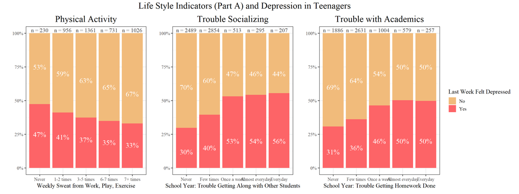

```r
# Outputs the final graph for life style (Part A)
final <- p1 + p2 + p3
final + plot_annotation('Life Style Indicators (Part A) and Depression in Teenagers',
                        theme = theme(plot.title = element_text(hjust = 0.45))) &
  theme(text = element_text('serif'),
        plot.title = element_text(size = 20))
```

The figure above suggests that increased physical activity may be related to decreased levels of depression, with the minimum level of exercise registering 47% of affirmative responses against 33% for the maximum level. In addition, the figure appears to indicate that respondents who report recurrent trouble with other students are more likely to experience depression (everyday trouble stands at 56% depression rates, while no troubles stands at 30%). Thirdly, the visualization seems to imply that increased academic troubles translate into higher depression records (50% depression rate in respondents with everyday troubles versus 31% among those with no troubles).

Nonetheless, confirmation of these preliminary observations is subject to sample size. On the one hand, for the study of physical activity, each dimension has a sufficient and comparable size (except for the Never level, which is expected of healthy teenagers). On the other hand, for the study of socializing and academic troubles, the highest order levels contain comparatively small sample sizes. As a result, the trends visualised could be spurious, coincidental, or biased to the limited number of respondents. It is also valuable to note that the life style indicators depicted in the figure aboce are likely to be intercorrelated. For instance, a teenager who has trouble with other students is less likely to engage in after-school activities, which in turn could hinder physical activity. Moreover, these relationships can be further studied by controlling for gender and socioeconomic factors, which are applied and discussed in the following section.

### Health Measure and Life Style (Part B)

```r
# Calculates and graphs depression given access to alcohol
labels <- data %>%
  filter(!is.na(`Easy Access Alcohol at Home`), !is.na(`Last Week Felt Depressed`)) %>%
  group_by(`Easy Access Alcohol at Home`, `Last Week Felt Depressed`) %>%
  summarise(count = n()) %>%
  mutate(perc = if_else(`Easy Access Alcohol at Home` == 'No', round(count/4622,2), round(count/1825,2)),
         perc=scales::percent(perc))
p1 <- data %>%
  filter(!is.na(`Easy Access Alcohol at Home`), !is.na(`Last Week Felt Depressed`)) %>%
  ggplot(aes(x = `Easy Access Alcohol at Home`, fill = `Last Week Felt Depressed`)) +
  geom_bar(position="fill", alpha = 1, show.legend = FALSE) +
  scale_y_continuous(labels = scales::percent) +
  labs(y = '', x = 'Easy Access to Alcohol at Home') +
  ggtitle('Access to Alcohol') +
  annotate("text", y = 0.70, x = 1, label = labels$perc[1], color = "white", size = 5.5, family ='serif') +
  annotate("text", y = 0.20, x = 1, label = labels$perc[2], color = "white", size = 5.5, family ='serif') +
  annotate("text", y = 0.75, x = 2, label = labels$perc[3], color = "white", size = 5.5, family ='serif') +
  annotate("text", y = 0.25, x = 2, label = labels$perc[4], color = "white", size = 5.5, family ='serif') +
  annotate("text", y = 1, x = 1, label = 'n = 4622', color = "gray27", vjust = -0.3, size = 4.5, family ='serif') +
  annotate("text", y = 1, x = 2, label = 'n = 1825', color = "gray27", vjust = -0.3, size = 4.5, family ='serif') +
  scale_fill_manual(values= wes_palette("GrandBudapest1", n = 4))  +
  theme_bw(base_size = 13) +
  theme(text = element_text(family = "serif"), plot.title = element_text(hjust = 0.5))
```

```r
# Calculates and graphs depression given first age of drugs (other than marihuana and cocaine) consumption
labels <- data %>%
  filter(!is.na(`Age First Drugs`), !is.na(`Last Week Felt Depressed`)) %>%
  group_by(`Age First Drugs`, `Last Week Felt Depressed`) %>%
  summarise(count = n()) %>%
  mutate(perc = case_when(`Age First Drugs` == '0. Never' ~ round(count/5900,2),
                          `Age First Drugs` == '1. Before 12 years old' ~ round(count/39,2),
                          `Age First Drugs` == '2. After 12 years old' ~ round(count/460,2)),
         perc=scales::percent(perc))
p2 <- data %>%
  filter(!is.na(`Age First Drugs`), !is.na(`Last Week Felt Depressed`)) %>%
  ggplot(aes(x = `Age First Drugs`, fill = `Last Week Felt Depressed`)) +
  geom_bar(position="fill", alpha = 1, show.legend = FALSE) +
  scale_y_continuous(labels = scales::percent) +
  labs(y = '', x = 'Age at which First Tried Drugs', caption = 'Drugs excluding marihuana and cocaine') +
  ggtitle('Ilegal Drugs Consumption') +
  scale_x_discrete(labels = c("0. Never" = "Never",
                             "1. Before 12 years old" = "Before 12 years old",
                             "2. After 12 years old" = "After 12 years old")) +
  annotate("text", y = 0.70, x = 1, label = labels$perc[1], color = "white", size = 5.5, family ='serif') +
  annotate("text", y = 0.20, x = 1, label = labels$perc[2], color = "white", size = 5.5, family ='serif') +
  annotate("text", y = 0.80, x = 2, label = labels$perc[3], color = "white", size = 5.5, family ='serif') +
  annotate("text", y = 0.30, x = 2, label = labels$perc[4], color = "white", size = 5.5, family ='serif') +
  annotate("text", y = 0.80, x = 3, label = labels$perc[5], color = "white", size = 5.5, family ='serif') +
  annotate("text", y = 0.30, x = 3, label = labels$perc[6], color = "white", size = 5.5, family ='serif') +
  annotate("text", y = 1, x = 1, label = 'n = 5900', color = "gray27", vjust = -0.3, size = 4.5, family ='serif') +
  annotate("text", y = 1, x = 2, label = 'n = 39', color = "gray27", vjust = -0.3, size = 4.5, family ='serif') +
  annotate("text", y = 1, x = 3, label = 'n = 460', color = "gray27", vjust = -0.3, size = 4.5, family ='serif') +
  scale_fill_manual(values= wes_palette("GrandBudapest1", n = 4))  +
  theme_bw(base_size = 13) +
  theme(text = element_text(family = "serif"), plot.title = element_text(hjust = 0.5))
```

```r
# Calculates and graphs depression given smoking habits
labels <- data %>%
  filter(!is.na(`Regular Smoker`), !is.na(`Last Week Felt Depressed`)) %>%
  group_by(`Regular Smoker`, `Last Week Felt Depressed`) %>%
  summarise(count = n()) %>%
  mutate(perc = if_else(`Regular Smoker` == 'No', round(count/1479,2), round(count/1285,2)),
         perc=scales::percent(perc))
p3 <- data %>%
  filter(!is.na(`Regular Smoker`), !is.na(`Last Week Felt Depressed`)) %>%
  ggplot(aes(x = `Regular Smoker`, fill = `Last Week Felt Depressed`)) +
  geom_bar(position="fill", alpha = 1) +
  scale_y_continuous(labels = scales::percent) +
  labs(y = '', x = 'Regular Smoker') +
  ggtitle('Smoking Habits') +
  annotate("text", y = 0.70, x = 1, label = labels$perc[1], color = "white", size = 5.5, family ='serif') +
  annotate("text", y = 0.20, x = 1, label = labels$perc[2], color = "white", size = 5.5, family ='serif') +
  annotate("text", y = 0.75, x = 2, label = labels$perc[3], color = "white", size = 5.5, family ='serif') +
  annotate("text", y = 0.25, x = 2, label = labels$perc[4], color = "white", size = 5.5, family ='serif') +
  annotate("text", y = 1, x = 1, label = 'n = 1479', color = "gray27", vjust = -0.3, size = 4.5, family ='serif') +
  annotate("text", y = 1, x = 2, label = 'n = 1285', color = "gray27", vjust = -0.3, size = 4.5, family ='serif') +
  scale_fill_manual(values= wes_palette("GrandBudapest1", n = 4))  +
  theme_bw(base_size = 13) +
  theme(text = element_text(family = "serif"), plot.title = element_text(hjust = 0.5))
```

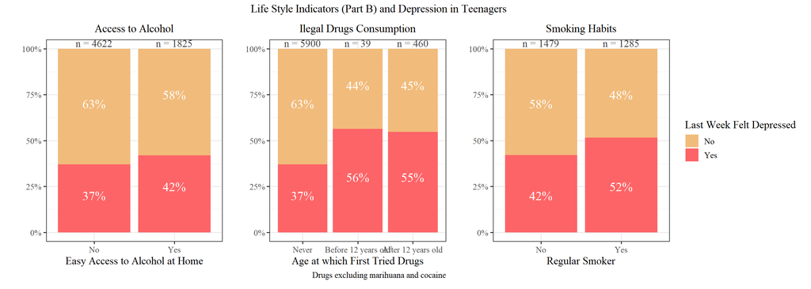

```r
# Outputs the final graph for life style (Part B)
final <- p1 + p2 + p3
final + plot_annotation('Life Style Indicators (Part B) and Depression in Teenagers', theme = theme(plot.title = element_text(hjust = 0.45))) &
  theme(text = element_text('serif'),
        plot.title = element_text(size = 14))
```

On the subject of Part B life style indicators, the figure above appears to indicate that alcohol, illegal drugs, and smoking are associated with depression. Nevertheless, it is important to take into consideration that these subjects can be sensitive to teenagers. Therefore, the self-reporting nature of the AdHealth data set may include significant bias prompted by the respondents’ tendency to lie/ minimize their answers. In relation, and as expected, dimensions as those concerning drug consumption have comparatively small sample sizes, which can distort the conclusions drawn.

### Gender and Socieconomic factors

```r
# Calculates and graphs depression answers by gender

labels <- data %>%
  filter(!is.na(`Last Week Felt Depressed`), !is.na(`Gender`)) %>%
  group_by(`Gender`, `Last Week Felt Depressed`) %>%
  summarise(count = n()) %>%
  mutate(perc = ifelse(`Gender` == 'Female', round(count/3347,2), round(count/3137,2)), perc=scales::percent(perc))
p1 <- data %>%
  filter(!is.na(`Last Week Felt Depressed`), !is.na(`Gender`)) %>%
  ggplot(aes(x = `Gender`, fill = `Last Week Felt Depressed`)) +
  geom_bar(position="dodge", alpha = 1, show.legend = FALSE) +
  labs(y = '') +
  ggtitle('Gender') +
  annotate("text", y = 750, x = 0.77, label = labels$perc[1], color = "white", size = 5.5, family ='serif') +
  annotate("text", y = 750, x = 1.23, label = labels$perc[2], color = "white", size = 5.5, family ='serif') +
  annotate("text", y = 750, x = 1.77, label = labels$perc[3], color = "white", size = 5.5, family ='serif') +
  annotate("text", y = 750, x = 2.23, label = labels$perc[4], color = "white", size = 5.5, family ='serif') +
  annotate("text", y = 1855, x = 1, label = 'n = 3347', color = "gray27", vjust = -0.3, size = 4.5, family ='serif') +
  annotate("text", y = 2150, x = 2, label = 'n = 3137', color = "gray27", vjust = -0.3, size = 4.5, family ='serif') +
  scale_fill_manual(values= wes_palette("GrandBudapest1", n = 4)) +
  theme_bw(base_size = 13) +
  theme(text = element_text(family = "serif"), plot.title = element_text(hjust = 0.5))
```

```r
# Calculates and graphs depression answers by school enrollment

labels <- data %>%
  filter(!is.na(`Last Week Felt Depressed`), !is.na(`Currently in School`)) %>%
  group_by(`Currently in School`, `Last Week Felt Depressed`) %>%
  summarise(count = n()) %>%
  mutate(perc = ifelse(`Currently in School` == 'No', round(count/125,2), round(count/6359,2)), perc=scales::percent(perc))
p2 <- data %>%
  filter(!is.na(`Last Week Felt Depressed`), !is.na(`Currently in School`)) %>%
  ggplot(aes(x = `Currently in School`, fill = `Last Week Felt Depressed`)) +
  geom_bar(position="fill", alpha = 1, show.legend = FALSE) +
  labs(y = '') +
  ggtitle('Currently in School') +
  scale_y_continuous(labels = scales::percent) +
  scale_fill_manual(values= wes_palette("GrandBudapest1", n = 4)) +
  annotate("text", y = 0.75, x = 1, label = labels$perc[1], color = "white", size = 5.5, family ='serif') +
  annotate("text", y = 0.30, x = 1, label = labels$perc[2], color = "white", size = 5.5, family ='serif') +
  annotate("text", y = 0.60, x = 2, label = labels$perc[3], color = "white", size = 5.5, family ='serif') +
  annotate("text", y = 0.20, x = 2, label = labels$perc[4], color = "white", size = 5.5, family ='serif') +
  annotate("text", y = 1, x = 1, label = 'n = 125', color = "gray27", vjust = -0.3, size = 4.5, family ='serif') +
  annotate("text", y = 1, x = 2, label = 'n = 6359', color = "gray27", vjust = -0.3, size = 4.5, family ='serif') +
  theme_bw(base_size = 13) +
  theme(text = element_text(family = "serif"), plot.title = element_text(hjust = 0.5))
```

```r
# Calculates and graphs depression answers by unemployment in the household

labels <- data %>%
  filter(!is.na(`Last Week Felt Depressed`), !is.na(`Unemployment Compensation`)) %>%
  group_by(`Unemployment Compensation`, `Last Week Felt Depressed`) %>%
  summarise(count = n())  %>%
  mutate(perc = ifelse(`Unemployment Compensation` == 'No', round(count/5282,2), round(count/277,2)),
         perc=scales::percent(perc))
p3 <- data %>%
  filter(!is.na(`Last Week Felt Depressed`), !is.na(`Unemployment Compensation`)) %>%
  ggplot(aes(x = `Unemployment Compensation`, fill = `Last Week Felt Depressed`)) +
  geom_bar(position="fill", alpha = 1) +
  labs(y = '') +
  ggtitle('Unemployment in the Household') +
  scale_y_continuous(labels = scales::percent) +
  annotate("text", y = 0.65, x = 1, label = labels$perc[1], color = "white", size = 5.5, family ='serif') +
  annotate("text", y = 0.15, x = 1, label = labels$perc[2], color = "white", size = 5.5, family ='serif') +
  annotate("text", y = 0.70, x = 2, label = labels$perc[3], color = "white", size = 5.5, family ='serif') +
  annotate("text", y = 0.20, x = 2, label = labels$perc[4], color = "white", size = 5.5, family ='serif') +
  annotate("text", y = 1, x = 1, label = 'n = 5282', color = "gray27", vjust = -0.3, size = 4.5, family ='serif') +
  annotate("text", y = 1, x = 2, label = 'n = 277', color = "gray27", vjust = -0.3, size = 4.5, family ='serif') +
  scale_fill_manual(values= wes_palette("GrandBudapest1", n = 4)) +
  theme_bw(base_size = 13) +
  theme(text = element_text(family = "serif"), plot.title = element_text(hjust = 0.5))
```

```r
# Calculates and graphs depression answers by unemployment in the household
p4 <- data %>%
  filter(!is.na(`Last Week Felt Depressed`), !is.na(`Household Income`), `Household Income` <= 100) %>%
  ggplot(aes(x = `Household Income`, y = `Last Week Felt Depressed`, fill = `Last Week Felt Depressed`)) +
  geom_boxplot(aes(middle = mean(`Household Income`))) +
  guides(fill = guide_legend(reverse = TRUE)) +
  labs(y = '') +
  ggtitle('Household Income') +
  annotate("text", y = 1.45, x = 40, label = 'Median', color = "gray27", size = 5.5, family ='serif') +
  annotate("text", y = 2.45, x = 35, label = 'Median', color = "gray27", size = 5.5, family ='serif') +
  annotate("text", y = 1.45, x = 24, label = 'Q1', color = "gray27", size = 5.5, family ='serif') +
  annotate("text", y = 2.45, x = 19, label = 'Q1', color = "gray27", size = 5.5, family ='serif') +
  annotate("text", y = 1.45, x = 58, label = 'Q3', color = "gray27", size = 5.5, family ='serif') +
  annotate("text", y = 2.45, x = 54, label = 'Q3', color = "gray27", size = 5.5, family ='serif') +
  annotate("text", y = 1.45, x = 100, label = '+1.5 IQR', color = "gray27", size = 5.5, family ='serif') +
  annotate("text", y = 2.45, x = 100, label = '+1.5 IQR', color = "gray27", size = 5.5, family ='serif') +
  annotate("text", y = 1.45, x = 0, label = '-1.5 IQR', color = "gray27", size = 5.5, family ='serif') +
  annotate("text", y = 2.45, x = 0, label = '-1.5 IQR', color = "gray27", size = 5.5, family ='serif') +
  annotate("text", y = 0.70, x = 54, label = 'n = 2921', color = "white", size = 5.5, family ='serif') +
  annotate("text", y = 1.70, x = 50, label = 'n = 1782', color = "white", size = 5.5, family ='serif') +
  scale_fill_manual(values= wes_palette("GrandBudapest1", n = 4)) +
  theme_bw(base_size = 13) +
  theme(text = element_text(family = "serif"), plot.title = element_text(hjust = 0.5), axis.text.y=element_blank(), axis.ticks.y=element_blank())
```

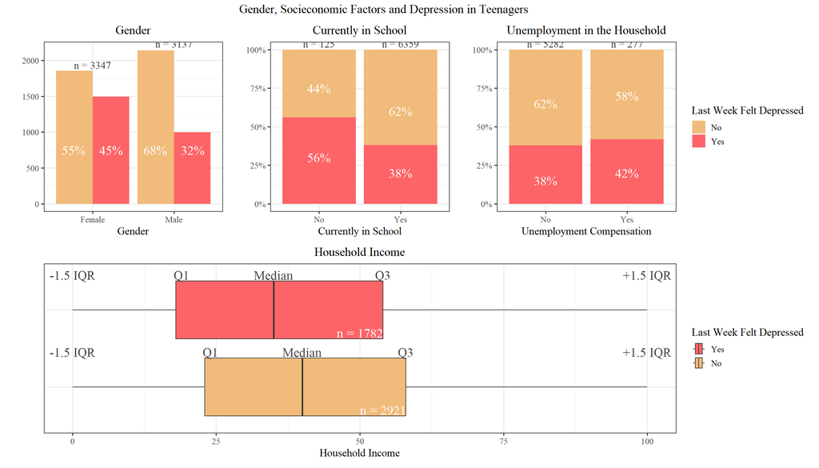

```r
# Outputs the final graph for depression given gender and socioeconomic factor
final <- (p1 + p2 + p3) /
  p4
final + plot_annotation('Gender, Socieconomic Factors and Depression in Teenagers', theme = theme(plot.title = element_text(hjust = 0.45))) &
  theme(text = element_text('serif'),
        plot.title = element_text(size = 15))
```

Concerning gender and socioeconomic factors, the figure above suggests that depression is more common among female respondents, as well as those not attending school, or experiencing unemployment in their household. In addition, the figure also seems to indicate that respondents in wealthier households are less prone to depression. Firstly, regarding gender, this conclusion aligns with the gender differences encountered in the literature review. Secondly, for school enrollment and household unemployment it is reasonable to assume that the conclusions may be spurious or biased given the large disparity in sample sizes. Lastly, on household income, it is important to consider that this factor may be correlated with an array of indicators which inflate the results. For instance, a wealthy household is likely to provide quality education, after-school sports/activities, and a buoyant social life.